# Inmunidad de Rebaño en dos palabras

Daniel Gervini

8/8/2020

# ¿Que es la inmunidad de rebaño?

A veces se escucha hablar en los medios de la “controvertida teoría de la inmunidad de rebaño”, como si la inmunidad de rebaño no fuera un hecho establecido. Lo que pasa es que se confunde el **hecho** de la inmunidad de rebaño con la búsqueda de la inmunidad de rebaño como **estrategia sanitaria**, que son dos cosas distintas. La inmunidad de rebaño existe y está dada por una fórmula muy simple: $1-1/R_0$. (De dónde sale esta fórmula, se explica [acá](https://dgervini.github.io/Coronavirus/Technical_details_T2C.html).)

Es decir que para un $R_0$ dado (mayor que 1), la inmunidad de rebaño se alcanza cuando se contagió el $(1-1/R_0)\times 100\%$ de la población. A partir de ese momento, el número de contagios diarios empieza a bajar (siempre que el $R_0$ se mantenga en el mismo valor).

Por lo tanto, hay dos escenarios para la evolución de una pandemia. El **escenario A** es cuando se logra un $R_0$ menor que 1: en ese caso la curva de contagios diarios *siempre* empieza a bajar, sin importar el nivel de infectados. El **escenario B** es cuando el $R_0$ es mayor que 1: en ese caso los contagios diarios bajarán recién cuando se llegue a un porcentaje de infectados del $(1-1/R_0)\times 100\%$.

La siguiente tabla muestra algunos valores posibles de $R_0$ y el correspondiente $(1-1/R_0)\times 100\%$, para tener una idea.

| $R_0$ | Porcentaje de infectados para inmunidad de rebaño |
| --- | --- |
| 1,02 | 2 % |
| 1,04 | 4 % |
| 1,06 | 6 % |
| 1,08 | 7 % |
| 1,10 | 9 % |
| 1,15 | 13 % |
| 1,20 | 17 % |
| 1,25 | 20 % |

Así, por ejemplo, si una ciudad logra mantener el $R_0$ en 1,04, se necesita que se contagie el 4% de la población para que la curva de casos diarios empiece a bajar.

# Ejemplos

## Ciudad de Buenos Aires

Calcular el $R_0$ es complicado porque hay que usar el modelo SIRD. En [este post](https://dgervini.github.io/Coronavirus/Historia_dos_ciudades) se estima que para la ciudad de Buenos Aires el $R_0$ está entre 1,04 y 1,10, por lo que la inmunidad de rebaño se alcanzaría con entre el 4% y el 9% de la población infectada. Al día de hoy la ciudad reporta 102.638 casos confirmados, lo que representa el 3,5% del total de 2.890.000 habitantes. Así que para un valor $R_0$ de 1,04 **prácticamente ya se alcanzó** la inmunidad de rebaño, así que la ciudad ya estaría atravesando el pico de la pandemia.

Por supuesto, a medida que la movilidad de las personas aumente, el $R_0$ también va a aumentar, por lo que si el $R_0$ sube a 1,10, digamos, va a haber un “rebrote” que lleve el número de casos al nivel correspondiente del 9% de la población, o sea 260.000 casos. Y así sucesivamente, si la movilidad y el $R_0$ siguen aumentando.

(Aclaración: el número de casos reales es mucho mayor al de casos confirmados por los tests, quizá hasta 10 veces más, pero en tal caso el $R_0$ real también es mucho mayor que 1,04, así que a fin de cuentas las dos cosas se compensan y las conclusiones son las mismas, sea que uno se base en los casos confirmados o en los casos supuestos.)

## Provincia de Buenos Aires

Para la Provincia de Buenos Aires, tomamos como población efectiva solamente los 10.894.664 de habitantes del conurbano bonaerense, porque en el resto de la provincia los casos son pocos, las poblaciones están más aisladas y el virus no circula con tanta facilidad.

Hecha esa aclaración, el $R_0$ también ha estado en un valor de alrededor de 1,04 en la provincia. La inmunidad de rebaño del 4% se va a alcanzar entonces cuando haya 436.000 casos confirmados. Pero el total de casos confirmados a la fecha es de 144.307, solo el 1,3% de la población, así que aún **está lejos el pico**.

¿Cuando se alcanzaría el pico en la provincia, entonces? Para tener una idea de la velocidad de crecimiento de casos, podemos graficar el cociente de los casos totales cada día sobre los casos totales del día anterior, lo que da el porcentaje diario de crecimiento:

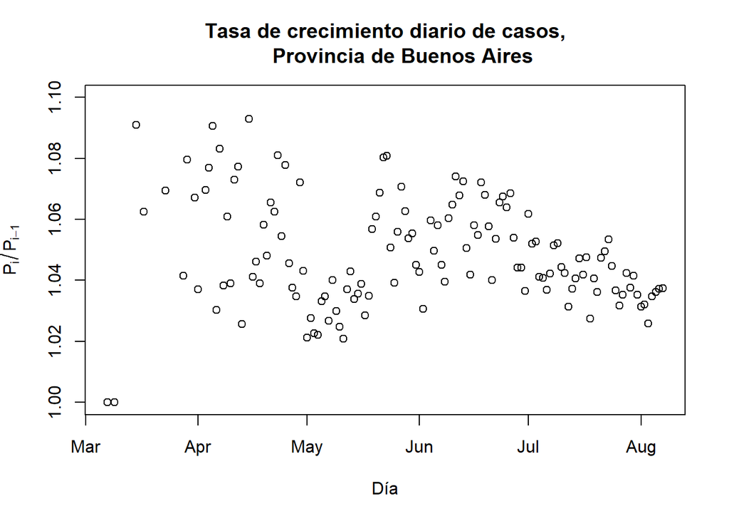

El promedio de crecimiento de los últimos 7 días fue de 3,35% diario. A esa velocidad se va a llegar a los 436.000 casos en 34 días, o sea que todavía **falta un mes** para que llegue el pico en la provincia de Buenos Aires.

[Back to blog](https://sites.uwm.edu/gervini/coronavirus-blog/)